# R Challenge 2 Group A1

# R Challenge 2 Group A1

### Loading the Libraries

```r
  library(dplyr)
  library(tidyverse)
  library(tidymodels)
  library(themis)
  library(recipes)
  library(rsample) # v fold cross validation
  library(ranger)
  library(kernlab)
  library(xgboost)
  library(parsnip)
  library(dials)
  library(ggplot2)
  library(doParallel)
  library(yardstick) # metrics
  library(LiblineaR) # Specifically for the SVM engine
  library(pROC)
  library(vip)
  # doParallel setup
  num_cores <- detectCores()
  registerDoParallel(cores = num_cores)

  # LOAD DATA
  crashes <- read_csv('crashes_2022.csv')
```

## Preliminary Work

Change all the column names to lowercase

```r
new_colnames <- tolower(colnames(crashes))
colnames(crashes) <- new_colnames
```

Create a new column called injuries that takes the value “injuries” if the value is greater than 0, and “none” otherwise

```r
crashes$injuries <- ifelse(crashes$injuries_total > 0, 'injuries', 'none')
```

Create new columns extracting date / time features from date column

```r
date_object <- as.POSIXct(crashes$date, format = "%Y-%m-%dT%H:%M:%OSZ", tz = "UTC")
date <- as.Date(crashes$date)
crashes$crash_month <- format(date_object, "%m")
crashes$crash_weekday <- weekdays(date)
crashes$crash_hour <- format(date_object, "%H")
```

Filter out columns that should not be included

```r
selected_features <- c("injuries", "crash_hour", "crash_weekday", "crash_month", "posted_speed_limit", "first_crash_type", "weather_condition", "lighting_condition", "roadway_surface_cond", "trafficway_type", "prim_contributory_cause", "latitude", "longitude")
```

Additionally, filter out all rows from the dataset where latitude > 0 and remove all samples that contain at least 1 missing value. Create a crashes_clean object with all these instructions

```r
crashes_clean <- crashes %>%
  select(all_of(selected_features)) %>%
  filter(latitude > 0) %>%
  drop_na()
```

Factoring:

```r
crashes_clean$injuries <- factor(crashes_clean$injuries, levels = c('none', 'injuries'))
crashes_clean$crash_hour <- factor(crashes_clean$crash_hour, levels = c('00', '01', '02', '03', '04', '05', '06', '07', '08', '09', '10', '11', '12', '13', '14', '15', '16', '17', '18', '19', '20', '21', '22', '23'))
crashes_clean$crash_weekday <- factor(crashes_clean$crash_weekday, levels = c('Monday', 'Tuesday', 'Wednesday', 'Thursday', 'Friday', 'Saturday', 'Sunday'))
crashes_clean$crash_month <- factor(crashes_clean$crash_month, levels = c('01', '02', '03', '04', '05', '06', '07', '08', '09', '10', '11', '12'))
crashes_clean$first_crash_type <- factor(crashes_clean$first_crash_type)
crashes_clean$weather_condition <- factor(crashes_clean$weather_condition)
crashes_clean$lighting_condition <- factor(crashes_clean$lighting_condition)
crashes_clean$roadway_surface_cond <- factor(crashes_clean$roadway_surface_cond)
crashes_clean$trafficway_type <- factor(crashes_clean$trafficway_type)
crashes_clean$prim_contributory_cause <- factor(crashes_clean$prim_contributory_cause)
```

## Questions

### Question 1

Create train and test datasets (crashes_train, crashes_test) from an initial split (crashes_split)

```r
set.seed(123)
crashes_split <- initial_split(crashes_clean, prop = 0.8, strata = injuries) #strata=injuries makes distribution of minority class similar in both datasets
crashes_train <- training(crashes_split)
crashes_test <- testing(crashes_split)
```

Check the % of occurences of the event whithin the dataset and take the appropriate action; use seed 123

Define tolerance for comparison

```r
tolerance <- 0.001 # 0.1%

# Calculate the percentage of 'injuries' in the original dataset
percentage_injuries_orig <- crashes_clean %>%
  filter(injuries == "injuries") %>%
  nrow() / nrow(crashes_clean) * 100

# Calculate the percentage of 'injuries' in the training dataset
percentage_injuries_train <- crashes_train %>%
  filter(injuries == "injuries") %>%
  nrow() / nrow(crashes_train) * 100

# Calculate the percentage of 'injuries' in the testing dataset
percentage_injuries_test <- crashes_test %>%
  filter(injuries == "injuries") %>%
  nrow() / nrow(crashes_test) * 100

# Check if the 'injuries' percentages are similar across all 3 datasets within the tolerance
if (abs(percentage_injuries_orig - percentage_injuries_train) <= tolerance &&
    abs(percentage_injuries_orig - percentage_injuries_test) <= tolerance &&
    abs(percentage_injuries_train - percentage_injuries_test) <= tolerance) {
  print("The percentage of 'injuries' is approximately the same across all datasets.")
} else {
  print("The percentage of 'injuries' differs by more than the specified tolerance across the datasets.")
}
```

```
[1] "The percentage of 'injuries' is approximately the same across all datasets."
```

The percentage of ‘injuries’ is approximately the same across all datasets.

No need to take further action as stratification was used in the initial split, ensuring that the percentage of ‘injuries’ is approximately the same across all datasets and this was validated.

### Question 2

In your training process you have decided to apply a 10 fold cross validation. Create the appropriate data structure to do so. Call the object crashes_folds; use seed 123. Consider the same as in the first question about the % of occurrences of the event.

```r
set.seed(123)
crashes_folds <- vfold_cv(data = crashes_train, v = 10, strata = injuries)
```

### Question 3

Create a recipe with the formula of the model applying to crashes_train and add a step to manage the inbalance of the target variable removing non-event samples. Call this object crashes_rec.

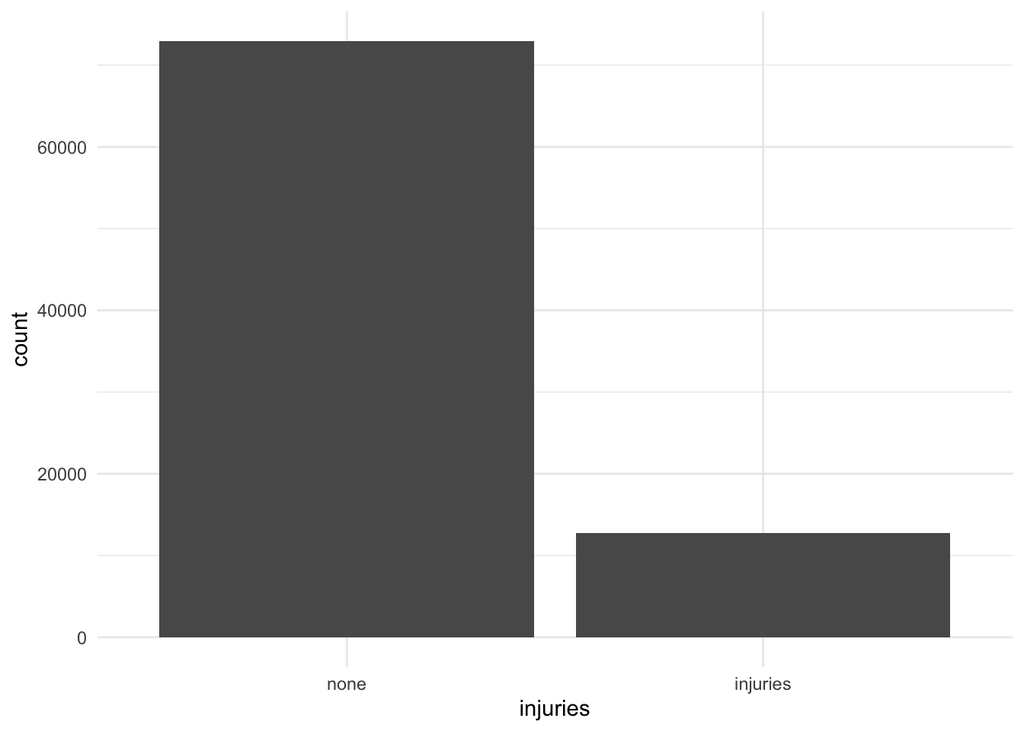

```r
# ggplot crashes_train classes to check imbalance -> reveals major imbalance between level 'none' and 'injuries' level.
ggplot(crashes_train, aes(x = injuries)) +
  geom_bar() +
  theme_minimal()
```

```r
### First recipe -------
set.seed(123) # Ensure reproducibility

# Now, create a recipe for the balanced dataset
crashes_rec <- recipe(injuries ~ ., data = crashes_train) %>%
  step_downsample(all_outcomes(), under_ratio = 1) # add a step that downsamples the majority class
```

Create a second recipe from crashes_rec to adapt your data in the case you want to use an algorithm than only accepts numerical data.

```r
### Second recipe to work only with numerical variables. -------
crashes_rec_num <- recipe(injuries ~ ., data = crashes_train) %>%
  step_dummy(all_nominal(), -all_outcomes()) %>%
  step_zv(all_predictors()) %>% # remove zero variance predictors
  step_corr(all_predictors()) %>% # remove highly correlated predictors
  step_normalize(all_numeric(), -all_outcomes()) %>% # normalize numeric predictors
  step_downsample(all_outcomes(), under_ratio = 1) # add a step that downsamples the majority class
```

### Question 4

Create a metrics set called crashes_metrics with all the metrics you consider necessary to evaluate the performance of the model.

```r
crashes_metrics <- metric_set(
  accuracy,
  sensitivity,
  roc_auc
)
# We decide to go on with these 3 metrics, it will be explained in the business case explanation
```

### Question 5

From here, is time to use different algorithms (try at least 3): The process is always the same:

- Create the specifications object, with the chosen algorithm (and its hyperparameters), the engine and the mode (in this case, classification).
- If the algorithm has hyperparameters, it’s a good idea to create a tune grid.
- Create the workflow that combine the recipe and the model (specifications) you want to use.
- Create a results object to tune the grid using the previous created objects: workflow, folds, grid and metrics. Keep in mind that some models would take a lot of time to train depending on the hyperparameter tuning grid you have created. Test first with a combination of hyperparameters not too aggressive. Hint: the libraries parallel, doParallel and foreach will help to parallelize workload and save time.
- Although tidymodels provides specific functions to train multiple combinations of models and recipes at once, for this exercise my recommendation is to train each algorithm separately. It will be easier for you to detect and fix errors without taking so much time.

Random Forest

```r
set.seed(123)

# Create the specification
rand_spec <- rand_forest(mtry = tune(),
                         trees = tune(),
                         min_n = tune()) %>%
  set_engine("ranger") %>% # ranger is a fast implementation of random forests
  set_mode("classification") # classification mode

# Create the grid
rand_grid <- grid_regular(
  mtry(range = c(6, 8)),
  trees(range = c(10, 12)),
  min_n(range = c(5, 7)),
  levels = 2 # This adjusts the number of levels per parameter, reducing the total combinations
)

# Create the workflow
rand_wf <- workflow() %>%
  add_recipe(crashes_rec_num) %>%
  add_model(rand_spec)

# Tune the grid
rand_results <- tune_grid(
  object = rand_wf,
  resamples = crashes_folds,
  grid = rand_grid,
  metrics = crashes_metrics,
  control = control_grid(save_pred = TRUE, parallel_over = "resamples")
)
```

Decision Tree

```r
set.seed(123)

# Create the specification including both parameters for tuning
tree_spec <- decision_tree(cost_complexity = tune(), tree_depth = tune()) %>%
  set_engine("rpart") %>%
  set_mode("classification")

# Create the workflow
tree_wf <- workflow() %>%
  add_recipe(crashes_rec_num) %>%
  add_model(tree_spec)

# Define a tuning grid including both cost_complexity and tree_depth
tree_grid <- grid_regular(
  cost_complexity(),  # Use default range for cost_complexity
  tree_depth(range = c(1, 5)),
  levels = 2
)

# Tune the model with parallel processing
tree_results <- tune_grid(
  object = tree_wf,
  resamples = crashes_folds,
  grid = tree_grid,
  metrics = crashes_metrics,
  control = control_grid(save_pred = TRUE, parallel_over = "everything")
)
```

XGBoost

```r
set.seed(123)

# Create the specification
xgb_spec <- boost_tree(mtry = tune()) %>%
  set_engine("xgboost") %>%
  set_mode("classification")

# Create the grid
xgb_grid <- grid_regular(mtry(range = c(5, 15)))

# Create the workflow
xgb_wf <- workflow() %>%
  add_recipe(crashes_rec_num) %>%
  add_model(xgb_spec)

# Tune the grid
xgb_results <- tune_grid(
  object = xgb_wf,
  resamples = crashes_folds,
  grid = xgb_grid,
  metrics = crashes_metrics,
  control = control_grid(save_pred = TRUE, parallel_over = "everything"))
```

### Question 6

From each model you train, evaluate the metrics according to the problem you want to solve. Is accuracy, sensitivity, roc_auc or precision the metric to optimize? Or is a compromise between some of them? Choose the final model to apply over test data and explain the reason you did that. Which are the values of the chosen metrics?

- Accuracy measures the proportion of correctly predicted outcomes (injuries) among all predictions
- Sensitivity measures the proportion of actual positive cases that were correctly identified
- Precision measures the proportion of positive identifications that were actually correct
- ROC AUC measures the area under the curve of the receiver operating characteristic (ROC) curve

Considering the objectives of our project, given the importance of accurately predicting injuries and identifying influential features, we aim to optimize the TP rate, therefore, a combination of accuracy and, most importantly, sensitivity might be most appropriate. This approach ensures that the model effectively captures instances of injury (TPs), thus providing actionable insights for injury prevention measures. Additionally, evaluating the ROC AUC can provide valuable information about the overall discriminatory power of the model. We will also have to account for model explainability and interpretability as it is key to understand the importance of each feature.

```r
rand_metrics <- rand_results %>%
  collect_metrics() %>%
  filter(.metric %in% c("accuracy", "sensitivity","roc_auc")) %>%
  group_by(.metric) %>%
  summarize(mean_estimate = mean(mean, na.rm = TRUE))

print(rand_metrics)
```

```
# A tibble: 3 × 2
  .metric     mean_estimate
  <chr>               <dbl>
1 accuracy            0.702
2 roc_auc             0.775
3 sensitivity         0.704
```

```r
tree_metrics <- tree_results %>%
  collect_metrics() %>%
  filter(.metric %in% c("accuracy", "sensitivity", "roc_auc")) %>%
  group_by(.metric) %>%
  summarize(mean_estimate = mean(mean, na.rm = TRUE))

print(tree_metrics)
```

```
# A tibble: 3 × 2
  .metric     mean_estimate
  <chr>               <dbl>
1 accuracy            0.398
2 roc_auc             0.627
3 sensitivity         0.307
```

```r
xgb_metrics <- xgb_results %>%
  collect_metrics() %>%
  filter(.metric %in% c("accuracy", "sensitivity", "roc_auc")) %>%
  group_by(.metric) %>%
  summarize(mean_estimate = mean(mean, na.rm = TRUE))

print(xgb_metrics)
```

```
# A tibble: 3 × 2
  .metric     mean_estimate
  <chr>               <dbl>
1 accuracy            0.710
2 roc_auc             0.788
3 sensitivity         0.711
```

XGBoost Model Selection:

1. High accuracy (0.71) and sensitivity (0.711) ensure reliable injury predictions.
2. Best ROC AUC (0.788) indicates strong ability to differentiate injury cases.
3. Provides key insights with feature importance, guiding preventive measures.
4. Regularization helps avoid overfitting, enhancing model reliability.

Conclusion: XGBoost’s performance and insights make it ideal for CPD’s safety goals.

### Question 7

You should finalize the workflow with the hyperparameters of your chosen model. With this updated workflow, fit over the split (train and test) and evaluate again the metrics. Have you avoided overfitting? Which are the values of the metrics?

Finalize the workflow with the hyperparameters of the chosen model (XGBoost)

```r
set.seed(123)
best_params <- select_best(xgb_results, "sensitivity")

#final_xgb_spec with best params
final_xgb_spec <- boost_tree(mtry = best_params$mtry) %>%
  set_engine("xgboost") %>%
  set_mode("classification")

final_xgb_wf <- workflow() %>%
  add_recipe(crashes_rec_num) %>%
  add_model(final_xgb_spec)

# Fit the model to the training data
final_xgb_fit <- final_xgb_wf %>%
  fit(data = crashes_train)

# Make predictions on the test data
final_xgb_predictions <- final_xgb_fit %>%
  predict(new_data = crashes_test) %>%
  bind_cols(crashes_test)

# Evaluate the model's performance on the test data
confusion_matrix <- conf_mat(final_xgb_predictions, truth = injuries, estimate = .pred_class)
summary(confusion_matrix)
```

```
# A tibble: 13 × 3
   .metric              .estimator .estimate
   <chr>                <chr>          <dbl>
 1 accuracy             binary         0.725
 2 kap                  binary         0.271
 3 sens                 binary         0.734
 4 spec                 binary         0.669
 5 ppv                  binary         0.927
 6 npv                  binary         0.306
 7 mcc                  binary         0.306
 8 j_index              binary         0.404
 9 bal_accuracy         binary         0.702
10 detection_prevalence binary         0.674
11 precision            binary         0.927
12 recall               binary         0.734
13 f_meas               binary         0.820
```

```r
# Ensure we predict probabilities
final_xgb_predictions_prob <- predict(final_xgb_fit, new_data = crashes_test, type = "prob")


### Checking for overfitting by only changing new_data to crashes_train and seing its performance
final_xgb_predictions_in_train <- final_xgb_fit %>%
  predict(new_data = crashes_train) %>%
  bind_cols(crashes_train)

# Evaluate the model's performance on the test data
final_xgb_metrics_in_train <- final_xgb_predictions_in_train %>%
  metrics(truth = injuries, estimate = .pred_class)

print(final_xgb_metrics_in_train)
```

```
# A tibble: 2 × 3
  .metric  .estimator .estimate
  <chr>    <chr>          <dbl>
1 accuracy binary         0.725
2 kap      binary         0.278
```

```r
# we also want to extract sensitivity and rocauc score
sensitivity(final_xgb_predictions_in_train, truth = injuries, estimate = .pred_class)
```

```
# A tibble: 1 × 3
  .metric     .estimator .estimate
  <chr>       <chr>          <dbl>
1 sensitivity binary         0.732
```

The metrics we got:  
In the test set:

- Accuracy: 0.725
- Sensitivity: 0.734

In the training set:

- Accuracy: 0.725
- Sensitivity: 0.732

The model is not overfitted as the metrics are very similar in both the training and test sets. The model is performing well in both sets, with high accuracy and sensitivity scores.

### Question 8

Create a plot to show the ROC curve.

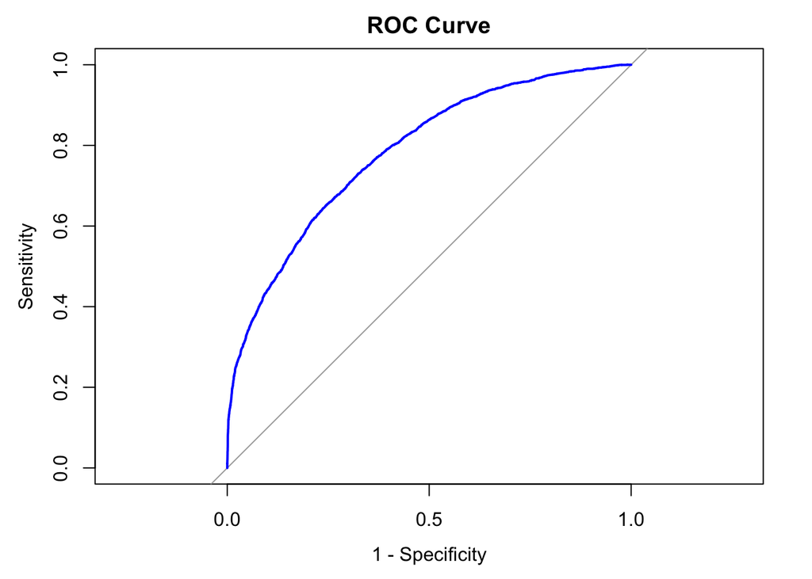

```r
roc_curve_data <- roc(crashes_test$injuries, final_xgb_predictions_prob$.pred_injuries)
plot(roc_curve_data, main = "ROC Curve", col = "blue", legacy.axes = TRUE,
     xlim = c(1, 0), ylim = c(0, 1))
```

### Question 9

Now, it’s time to extract all the information stored in the .workflow column of the final fit. Create an object called crashes_pedictor for predicting new instances when necessary

```r
last_fit <- last_fit(
  object = final_xgb_wf,
  split = crashes_split,
  metrics = crashes_metrics)

crashes_predictor <- last_fit$.workflow[[1]]
```

### Question 10

From this object create a plot ranking in descending order the variable importance. Which are the 4 first variables?

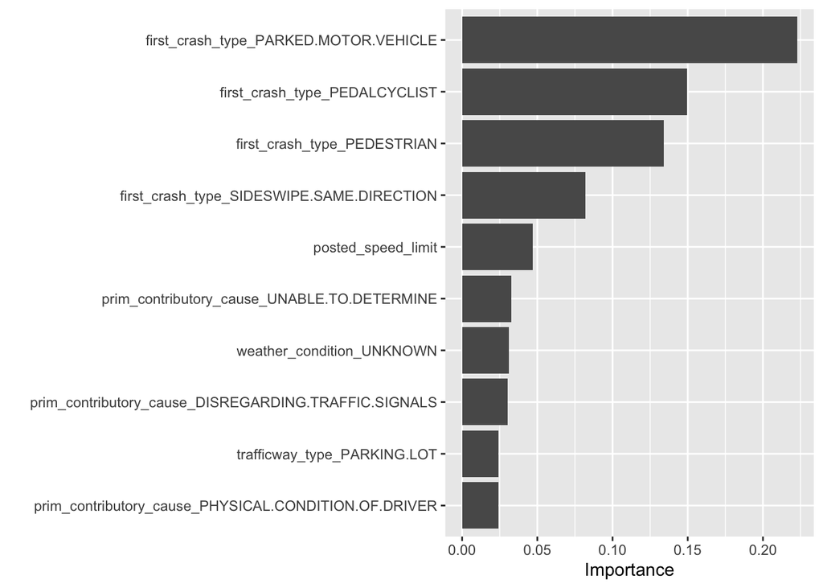

```r
# use 'vip' to plot the variable importance
vip_plot <- vip(crashes_predictor, num_features = 10)
print(vip_plot)
```

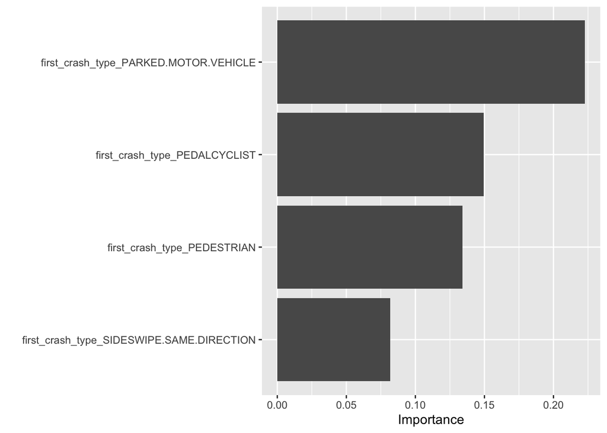

```r
# To directly extract and print the top 4 important variables
top_variables <- vip(crashes_predictor, num_features = 4, geom = NULL)
print(top_variables)
```

### Question 11

Predict the entire dataset (crashes_clean) with your model and plot a heatmap of the predicted injuries (consider aggregating the results in some way to obtain the desired visualization).

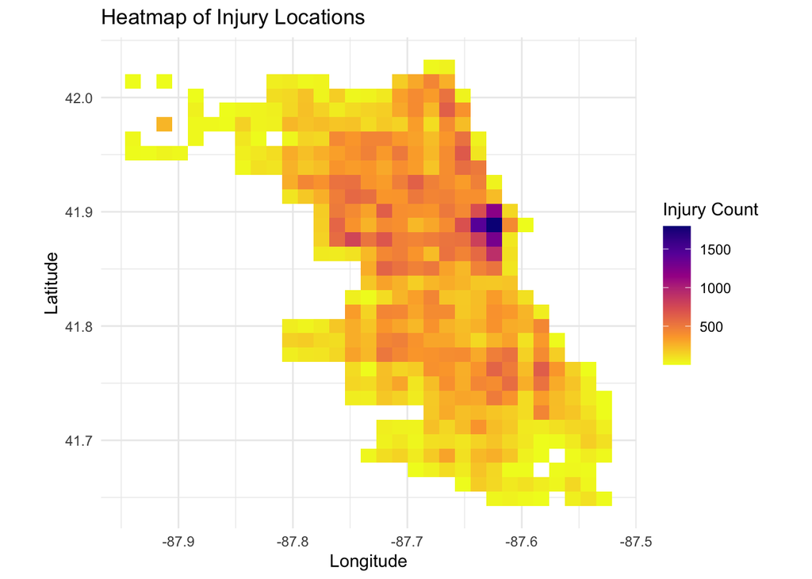

```r
# Predict the entire dataset
crashes_predictions_injuries <- final_xgb_fit %>%
  predict(new_data = crashes_clean) %>%
  bind_cols(crashes_clean)

crashes_predictions_injuries <- final_xgb_fit %>%
  predict(new_data = crashes_clean) %>%
  bind_cols(crashes_clean)


heatmap <- ggplot(crashes_predictions_injuries, aes(x = longitude, y = latitude)) +
  geom_bin2d(bins = 30) +  # Adjust the number of bins as needed to get the desired resolution
  scale_fill_viridis_c(option = "C", direction = -1, name = "Injury Count") +
  labs(title = "Heatmap of Injury Locations",
       x = "Longitude",
       y = "Latitude") +
  theme_minimal() +
  coord_fixed()  # Keep aspect ratio of 1 to avoid distortion

print(heatmap)
```

### Question 12

According to a visual inspection of the heatmap, subset the data geographically (the most crashes-prone area) and analyze according to the most important features in Q10. Which recommendations would you give to the CPD about this high-incident zone? Write at least two.

```r
# Subset the data geographically to the most crash-prone area
high_incident_zone <- crashes_predictions_injuries %>%
  filter(latitude > 41.8 & latitude < 41.9 & longitude > -87.7 & longitude < -87.6)

# Analyze the data based on the most important features
high_incident_zone_summary <- high_incident_zone %>%
  group_by(first_crash_type) %>%
  summarize(count = n()) %>%
  arrange(desc(count))

print(high_incident_zone_summary)
```

```
# A tibble: 18 × 2
   first_crash_type             count
   <fct>                        <int>
 1 REAR END                      4708
 2 PARKED MOTOR VEHICLE          4670
 3 SIDESWIPE SAME DIRECTION      4346
 4 TURNING                       3841
 5 ANGLE                         2669
 6 FIXED OBJECT                  1204
 7 PEDESTRIAN                     634
 8 PEDALCYCLIST                   441
 9 REAR TO FRONT                  390
10 OTHER OBJECT                   281
11 SIDESWIPE OPPOSITE DIRECTION   257
12 REAR TO SIDE                   202
13 HEAD ON                        154
14 OTHER NONCOLLISION              78
15 REAR TO REAR                    54
16 OVERTURNED                      18
17 ANIMAL                           8
18 TRAIN                            1
```

Recommendations:

1. Implement targeted safety campaigns focussing on the most common crash types within the high-incident area, such as REAR END, PARKED MOTOR VEHICLE, and SIDESWIPE SAME DIRECTION

   Examples:

   1.1 **Rear End Collisions**: Launch a comprehensive educational campaign aimed at reducing tailgating and promoting safe following distances. Further, use dynamic signage that displays safe following times in seconds, and incorporate technology such as in-vehicle alerts for following too closely

   1.2 **Parked Motor Vehicle Incidents**: Develop a public service announcement series and distribute it via social media, local TV, and radio, focusing on the importance of checking mirrors and blind spots before exiting or entering a parked state. To add on that, promote the use of technology like reverse sensing systems and side-view assist in newer vehicles.

   1.3 **Sideswipe:** Initiate a ‘Stay in Lane’ campaign to emphasize lane discipline. This should include the promotion of turn signal usage, the dangers of distracted driving, and the importance of being attentive to lane changes, especially on multi-lane roads.
2. Enhance road infrastructure to address common crash scenarios, such as TURNING and ANGLE CRASHES, reducing the frequency of these accidents

   Examples:

   2.1 **Turning Accidents**: Improve intersection design by incorporating dedicated turning lanes with clear signage and signals and implement intelligent traffic light systems that adapt in real-time to traffic flow, reducing congestion and the risk of turning accidents.

   2.2 **Angle Crashes**: Retrofit dangerous intersections with roundabouts which decrease the occurrence of angle crashes. Upgrade lighting at intersections and install reflective road markers to enhance visibility.
3. Collaborate with local authorities to enforce traffic regulations and improve road safety awareness among road users in the high-incident zone
4. Conduct regular safety assessments and data-driven analyses to identify emerging trends / a change in the trends and prioritize interventions to enhance public safety